# npm-summary

This notebook shows the analysis of npm modules created by the `npm-summary` command and its friends.

> Note that some of the analysis is done manually so reruning the notebook on different data will give you different results, but won’t change the manual analysis.

## NPM Packages Summary

The summary table contains info about unique paths from all projects and splits them into npm and non-npm paths.

```r
psum = readDataset("npm-summary.csv")
LOG("Total projects", d = nrow(psum))
```

```
Total projects: 2234834
```

```r
LOG("With NPM files", d = nrow(psum %>% filter(numNPMPaths > 0)), pct = nrow(psum))
```

```
With NPM files: 175953 (7.87%)
```

Since the other columns in the summary table are only approximations, we are not going to deal with them. Their more fine grained and non approximative versions are calculated from the details below.

## Package Details

The package details table contains information about packages found in projects. For each tuple (projectId,packagePath) it contains a record summarizing the lifetime of that package.

```r
pds = readDataset("npm-summary-details.csv")
pds$name = factor(pds$name)
LOG("Total number of records", d = nrow(pds))
```

```
Total number of records: 43788875
```

```r
LOG("Unique packages", d = length(levels(pds$name)))
```

```
Unique packages: 66783
```

We can have a look at the package frequencies now:

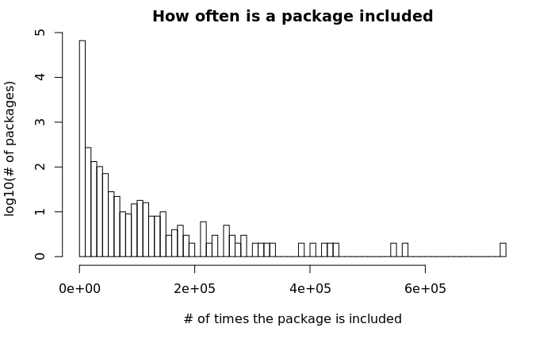

```r
x = pds %>% group_by(name) %>% summarize(count = n())
h = hist(x$count, breaks = 100, plot = F)
h$counts =log10(h$counts + 1)
plot(h, ylab="log10(# of packages)", xlab = "# of times the package is included", main = "How often is a package included")
```

```r
DT::datatable(x %>% arrange(desc(count)) %>% head(100) %>% mutate(url = A(name, npmPackageUrl(name))) %>% select(url,count), escape = F)
```

|  | url | count |
| --- | --- | --- |
| 1 | inherits | 733169 |
| 2 | isarray | 564092 |
| 3 | readable-stream | 541225 |
| 4 | debug | 448058 |
| 5 | string_decoder | 434142 |
| 6 | core-util-is | 420249 |
| 7 | ms | 408112 |
| 8 | minimist | 387206 |
| 9 | ansi-regex | 332637 |
| 10 | minimatch | 327014 |

[output cut: 90 more lines]

Ok, next step is to remove data that make sense:)

First we remove those records, where we haven’t seen any package.json. This means that it is not a proper NPM package, therefore any changes to it are ok, since we are interested in changes to NPM packages alone.

```r
x = pds %>% filter(numVersions != 0)
LOG("No package.json present", d = nrow(pds) - nrow(x), pct = nrow(pds))
```

```
No package.json present: 420730 (0.96%)
```

Second, it might be interesting to see what happens to the files in the remaining packages. For this we exclude two groups of packages. Those that were *never* touched in any way after they were included and those that were actually completely deleted.

```r
x = pds %>% filter(numVersions == 1 & numManualChanges == 0 & numDeletions == 0)
LOG("No changes at all", d = nrow(x), pct = nrow(pds))
```

```
No changes at all: 27883810 (63.68%)
```

```r
x = pds %>% filter(numActiveFiles == 0 & numVersions > 0)
LOG("Entirely removed", d = nrow(x), pct = nrow(pds))
```

```
Entirely removed: 14095837 (32.19%)
```

Now the entirely removed number of packages is not that informative on its own, but we can look at this from the point of projects, i.e. how many unique projects store their npm files and how many of these delete *all* their npm_modules, since these have most likely included them by mistake anyways… (?)

```r
# get all projects
projsAll = pds %>% filter(numVersions != 0) %>% group_by(projectId) %>% summarise(packages = n())
# get all projects that delete at least one package
projsDeleted = pds %>% filter(numVersions != 0 & numActiveFiles == 0) %>% group_by(projectId) %>% summarise(deleted = n())
# join them
projs = merge(projsAll, projsDeleted, by="projectId", all = T)
projs$deleted[is.na(projs$deleted)] = 0
projs$survived = projs$packages - projs$deleted
projs$projectName = projectName(projs$projectId)
projs$projectUrl = projectUrl(projs$projectId)
LOG("Projects which delete all packages", d = nrow(projs %>% filter(survived == 0)), pct = nrow(projs))
```

```
Projects which delete all packages: 42829 (24.84%)
```

We can also look at the projects that deleted the most, but not all packages:

```r
DT::datatable(projs %>% filter(survived > 0, deleted > 0) %>% arrange(desc(deleted / packages)) %>% head(100) %>% mutate(url = A(projectName, projectUrl), pctDeleted = deleted * 100 / packages ) %>% select(url,packages, deleted, survived, pctDeleted), escape = F)
```

|  | url | packages | deleted | survived | pctDeleted |
| --- | --- | --- | --- | --- | --- |
| 1 | dearvikki/office-home | 2619 | 2618 | 1 | 99.9618174875907 |
| 2 | jsmulrow/mashup | 2407 | 2406 | 1 | 99.9584545076859 |
| 3 | eightshapes/esds-build | 1972 | 1971 | 1 | 99.9492900608519 |
| 4 | amunra81/projects | 1449 | 1448 | 1 | 99.9309868875086 |
| 5 | alyssonnaz/web.application | 1425 | 1424 | 1 | 99.9298245614035 |
| 6 | utsavpreet/minorproject-docbot | 1359 | 1358 | 1 | 99.9264164827079 |
| 7 | jaraquistain/otl | 1223 | 1222 | 1 | 99.9182338511856 |
| 8 | nise/vi-lab | 1145 | 1144 | 1 | 99.9126637554585 |
| 9 | launakay/databagel | 1119 | 1118 | 1 | 99.9106344950849 |
| 10 | apjs/reactvelocity | 1105 | 1104 | 1 | 99.9095022624434 |

[output cut: 90 more lines]

Ok. I’ve looked at some randomly, the one surviving package was not in node_modules folder, but elsewhere. This makes sense.

Now let’s look at the number of versions of the packages we see, counting only those with no manual changes - here it is basically an update to the node package stored in the repo:

```r
x = pds %>% filter(numVersions > 0 & numManualChanges == 0 & numDeletions == 0)
LOG("No manual changes", d = nrow(x), pct = nrow(pds))
```

```
No manual changes: 28756098 (65.67%)
```

```r
summary(x$numVersions)
```

```
   Min. 1st Qu.  Median    Mean 3rd Qu.    Max.
  1.000   1.000   1.000   1.036   1.000  32.000
```

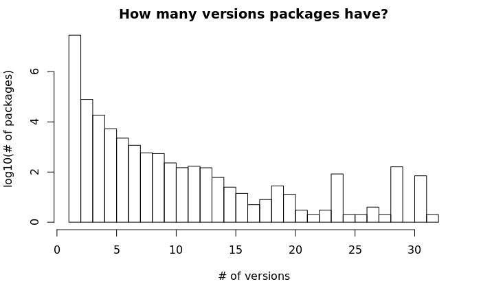

```r
h = hist(x$numVersions, breaks = max(x$numVersions), plot = F)
h$counts =log10(h$counts + 1)
plot(h, ylab="log10(# of packages)", xlab = "# of versions", main = "How many versions packages have?")
```

Let’s see the packages with most version changes now:

```r
DT::datatable(x %>% arrange(desc(numVersions)) %>% head(100) %>% mutate(url = A(projectName(projectId), projectUrl(projectId))) %>% select(projectId, url,path,name, numVersions), escape = F)
```

```
It seems your data is too big for client-side DataTables. You may consider server-side processing: https://rstudio.github.io/DT/server.htmlIt seems your data is too big for client-side DataTables. You may consider server-side processing: https://rstudio.github.io/DT/server.html
```

|  | projectId | url | path | name | numVersions |
| --- | --- | --- | --- | --- | --- |
| 1 | 816834 | danleavitt0/ev3-server | node_modules/ev3-api | ev3-api | 32 |
| 2 | 581177 | vforge/.atom | packages/language-babel/node_modules/concat-map | concat-map | 31 |
| 3 | 581177 | vforge/.atom | packages/language-babel/node_modules/slash | slash | 31 |
| 4 | 581177 | vforge/.atom | packages/language-babel/node_modules/js-tokens | js-tokens | 31 |
| 5 | 581177 | vforge/.atom | packages/language-babel/node_modules/strip-ansi | strip-ansi | 31 |
| 6 | 581177 | vforge/.atom | packages/language-babel/node_modules/escape-string-regexp | escape-string-regexp | 31 |
| 7 | 581177 | vforge/.atom | packages/language-babel/node_modules/brace-expansion | brace-expansion | 31 |
| 8 | 581177 | vforge/.atom | packages/language-babel/node_modules/supports-color | supports-color | 31 |
| 9 | 581177 | vforge/.atom | packages/language-babel/node_modules/wrappy | wrappy | 31 |
| 10 | 581177 | vforge/.atom | packages/language-babel/node_modules/globals | globals | 31 |

[output cut: 90 more lines]

the vforge-atom, which is almost all of the table is someone’s private configuration for atom, where he archives the packages his atom uses apparently.

The first one is a repo that includes node_modules folder my mistake I assume, that was reasonably actively developed over the time. A few other packages were also updated there, which seems reasonable:

```r
DT::datatable(x %>% filter(projectId == 816834) %>% arrange(desc(numVersions)) %>% head(100) %>% mutate(url = A(projectName(projectId), projectUrl(projectId))) %>% select(url,path,name, numVersions), escape = F)
```

```
It seems your data is too big for client-side DataTables. You may consider server-side processing: https://rstudio.github.io/DT/server.htmlIt seems your data is too big for client-side DataTables. You may consider server-side processing: https://rstudio.github.io/DT/server.html
```

|  | url | path | name | numVersions |
| --- | --- | --- | --- | --- |
| 1 | danleavitt0/ev3-server | node_modules/ev3-api | ev3-api | 32 |
| 2 | danleavitt0/ev3-server | node_modules/rtm-server | rtm-server | 5 |
| 3 | danleavitt0/ev3-server | node_modules/ev3-api/node_modules/ev3-js-devices | ev3-js-devices | 3 |
| 4 | danleavitt0/ev3-server | node_modules/ev3-js-device | ev3-js-device | 3 |
| 5 | danleavitt0/ev3-server | node_modules/ev3-js-devices | ev3-js-devices | 2 |
| 6 | danleavitt0/ev3-server | node_modules/fsevents/node_modules/once | once | 1 |
| 7 | danleavitt0/ev3-server | node_modules/resolve/test/resolver/biz/node_modules/garply | garply | 1 |
| 8 | danleavitt0/ev3-server | node_modules/anymatch | anymatch | 1 |
| 9 | danleavitt0/ev3-server | node_modules/binary-extensions | binary-extensions | 1 |
| 10 | danleavitt0/ev3-server | node_modules/is-primitive | is-primitive | 1 |

[output cut: 90 more lines]

Now that we know most of the packages are never touched, let’s actually see those that are touched manually:

```r
x = pds %>% filter(numVersions > 0 & numDeletions > 0)
LOG("Manual deletions", d = nrow(x), pct = nrow(pds))
```

```
Manual deletions: 14566329 (33.26%)
```

```r
x = pds %>% filter(numVersions > 0 & numManualChanges > 0)
LOG("Manual changes", d = nrow(x), pct = nrow(pds))
```

```
Manual changes: 89921 (0.21%)
```

Ok, only tiny tiny part of the dataset ever gets manually changed, the next section looks into more details in these alone:

## Manual analysis of manual changes

Now, we load the manual changes, randomly select a few and then analyze them.

```r
manualChanges = readDataset("npm-summary-manualChanges.csv")
manualChangesSample = manualChanges %>% sample_n(20)
```

Since we analyze these manually in the later stage, we must freeze them in time, which was done by running:

```
cat(paste0(deparse(manualChangesSample), collapse = ""))
```

And we now overwrite the manualChangesSample with the frozed values:

```r
manualChangesSample = structure(list(projectId = c(534843, 100530, 194040, 63301, 999740, 1442666, 1375196, 2163150, 1084459, 2236645, 383922, 1093779, 2219509, 1375196, 2132233, 424899, 63301, 1289792, 1375196, 1339568), commitId = c(54248950, 12287640, 21689997, 8354893, 94571253, 129032653, 123895794, 183584648, 101238459, 188580207, 39197460, 101881879, 187372597, 123895831, 181216405, 42745968, 8354815, 117808242, 123895451, 121348581), pathId = c(6844, 15406567, 18245997, 10307395, 15616766, 144612527, 138472513, 56722, 46126919, 206877063, 46730642, 98917, 205088652, 138472490, 377934, 51027504, 10307427, 10307864, 138472487, 8939783), contentsId = c(54248239, 12285900, 21689931, 8353181, 94571078, 129032459, 123892740, 183584618, 101237635, 188579798, 39197378, 101881834, 187370854, 123892430, 181216377, 42745932, 8352393, 117808103, 123892316, 121348106)), class = c("spec_tbl_df", "tbl_df", "tbl", "data.frame"), row.names = c(NA, -20L), spec = structure(list(cols = list(    projectId = structure(list(), class = c("collector_double",     "collector")), commitId = structure(list(), class = c("collector_double",     "collector")), pathId = structure(list(), class = c("collector_double",     "collector")), contentsId = structure(list(), class = c("collector_double",     "collector"))), default = structure(list(), class = c("collector_guess", "collector")), skip = 1), class = "col_spec"))
```

Add columns with extra information that allows us to link to github directly:

```r
manualChangesSample$projectName = projectName(manualChangesSample$projectId)
manualChangesSample$projectUrl = projectUrl(manualChangesSample$projectId)
manualChangesSample$commitHash = objectHashes(manualChangesSample$commitId)
manualChangesSample$path = filePaths(manualChangesSample$pathId)
```

And actually look at what we have produced:

```r
x = data.frame(
    project = A(manualChangesSample$projectName, manualChangesSample$projectUrl),
    file = A(manualChangesSample$path,commitUrl(manualChangesSample$projectUrl, manualChangesSample$commitHash))
)
DT::datatable(x, escape = F)
```

Here is the table of manual findigs:

| row | project | file | Comments |
| --- | --- | --- | --- |
| 1 | hopeatina/hiw | node_modules/express/node_modules/connect/lib/proto.js | ~5000 changed files, likely not by hand |
| 2 | greebowarrior/nessa | server/node_modules/nodetv-movies/index.js | private package |
| 3 | noneedsystem/testing | node_modules/locomotive/bin/lcm.js | ~800 changes, looks like code formatting only |
| 4 | mercmobily/hotplate | node_modules/hotDojoStores/client/AppStoreNotify.js | likely private |
| 5 | karenpeng/myvoxel | node_modules/voxel-engine/node_modules/voxel-control/index.js | manual change, did introduce debugging comments before, this removes them |
| 6 | lauren/open-in-spotify | node_modules/mocha/node_modules/growl/test.min.js | 95 changes, extra commit to add mocha files, seems to follow growl repo |
| 7 | zhangmhao/life-time-tracker | node_modules/tracker/search/Routine.js | looks like private package, but a large one, in chinese so I don’t properly understand the context |
| 8 | taro-m/scripting-server | node_modules/uglify-js/lib/parse.js | copies change from original package |
| 9 | perjansson/yabt | node_modules/angular2/ts/src/core/application_common_providers.js | ~1100 changes, likely not by hand |
| 10 | thiq/scripts | node_modules/economy/index.js | private |
| 11 | geon/progres | node_modules/progres/index.js | private |
| 12 | icefox0801/jquery-plugin | node_modules/grunt/node_modules/findup-sync/node_modules/lodash/dist/lodash.underscore.js | copies change from original package (likely, its really old) |
| 13 | synchrolabs/synchroserver | SynchroServer/node_modules/synchro-web/client/controls/web-gridview-wrapper.js | private |
| 14 | zhangmhao/life-time-tracker | node_modules/tracker/server/AchieveGoal.js | the same chinese guy as above, looks private |
| 15 | sawbones/gameencode | node_modules/socket.io/node_modules/socket.io-client/lib/io.js | likely mirrors changes from package |
| 16 | artoale/karma-brackets | node/node_modules/karma/lib/server.js | removed possibly local debug output |
| 17 | mercmobily/hotplate | node_modules/hotDojoDgridWidgets/lib/hotDojoDgridWidgets.js | likely private |
| 18 | mercmobily/bookingdojo | node_modules/bd/lib/bd.js | likely private |
| 19 | zhangmhao/life-time-tracker | node_modules/tracker/conf/defaultSettings.json | the chinese guy again, private |
| 20 | duknic/regex-detective | node_modules/express-stormpath/node_modules/stormpath/docs/karma.conf.js | ~3100 files, likely not manual |

To summarize the table above:

- 10 (50%) are private packages, or suspected private (i.e. not in NPM)
- 4 (20%) are extensive changes to many many files which are likely not manual
- 4 (20%) are mirroring changes from the original package
- 2 (10%) addition or removal of debug prints